# Seguridad y percepción ciudadana en Querétaro

Data_Frame,wendolyn Sóstenes Gómez, José Manuel Flores Reséndiz, Jesús Gabriel Díaz

2026-05-03

## Índice

**1.** Introducción

**2.** Percepción ciudadana sobre seguridad y confianza social  
2.1 Corrupción  
2.2 Guardia Nacional  
2.3 Percepción sobre la seguridad al caminar por las noches  
2.4 Percepción futura sobre la seguridad pública en su colonia  
2.5 Confianza vecinal

**3.** Impacto de la delincuencia en actividades cotidianas  
3.1 Trabajo inseguro  
3.2 Abandono escolar por temor a ser víctimas de la delincuencia  
3.3 Robo de celular

**4.** Estrategias de prevención y respuesta comunitaria  
4.1 Adquirir un perro guardián  
4.2 Organización vecinal por alumbrado

**5.** Conclusiones

**6.** Referencias

## 1.Introducción

La seguridad pública constituye una dimensión fundamental para el bienestar social y el desarrollo territorial. Su análisis no se limita a la incidencia delictiva registrada por las instituciones, sino que también incluye la percepción ciudadana, la experiencia de victimización y las medidas preventivas adoptadas por la población ante situaciones de riesgo.

En este contexto, el Instituto Nacional de Estadística y Geografía (INEGI), a través de la Encuesta Nacional de Victimización y Percepción sobre Seguridad Pública (ENVIPE), genera información estadística que permite conocer cómo la población percibe la seguridad, cuáles son los delitos más frecuentes y qué estrategias implementan los hogares para protegerse.

Por esta razón, el análisis presentado se limita a estos tres municipios, ya que los factores de expansión y el diseño muestral de la ENVIPE solo permiten realizar inferencias válidas para dichas áreas urbanas. Aunque existen registros individuales de otras localidades, estos no cuentan con representatividad estadística suficiente para expandirse a nivel municipal, por lo que utilizarlos con ese fin podría generar interpretaciones sesgadas o resultados poco confiables.

De esta manera, el estudio busca identificar patrones territoriales y diferencias locales en materia de percepción de inseguridad, victimización y medidas de prevención dentro de las áreas urbanas de interés consideradas por la encuesta en el estado de Querétaro.

## 2. Percepción ciudadana sobre seguridad y confianza social

## 2.1 Corrupción

La percepción social de la seguridad permite identificar cómo la ciudadanía interpreta su entorno y la actuación de las instituciones. (La pregunta indagó sobre las tres problemáticas de mayor preocupación; los datos se presentan por la frecuencia de las menciones sin el orden. A nivel nacional 94 525 160 casos mencionan tres, 405 923 dos y 322 566 sólo una).

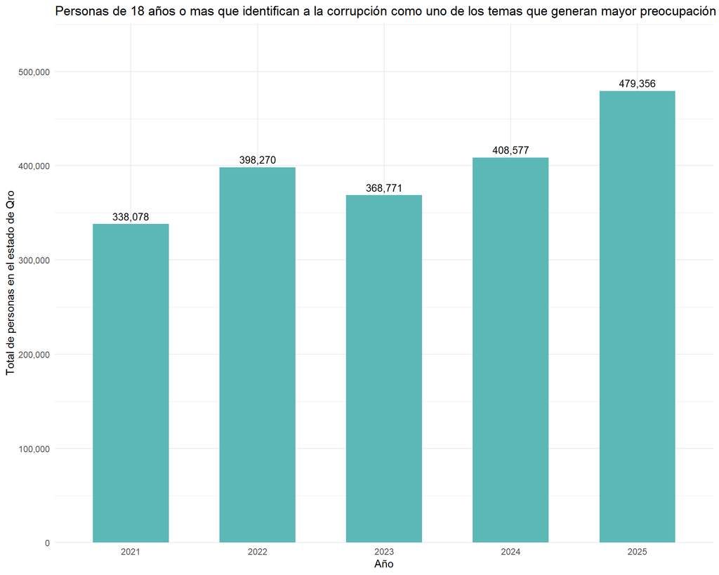

## Percepción de corrupción por municipio

La dimensión territorial permite observar cómo esta percepción se distribuye en el estado y qué municipios concentran mayores niveles de preocupación respecto a la corrupción.

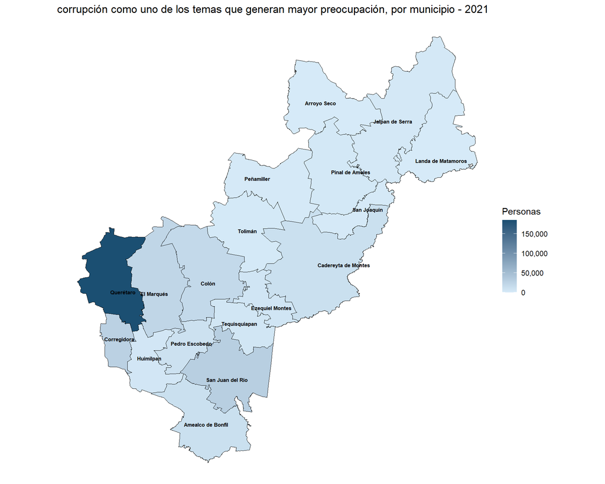

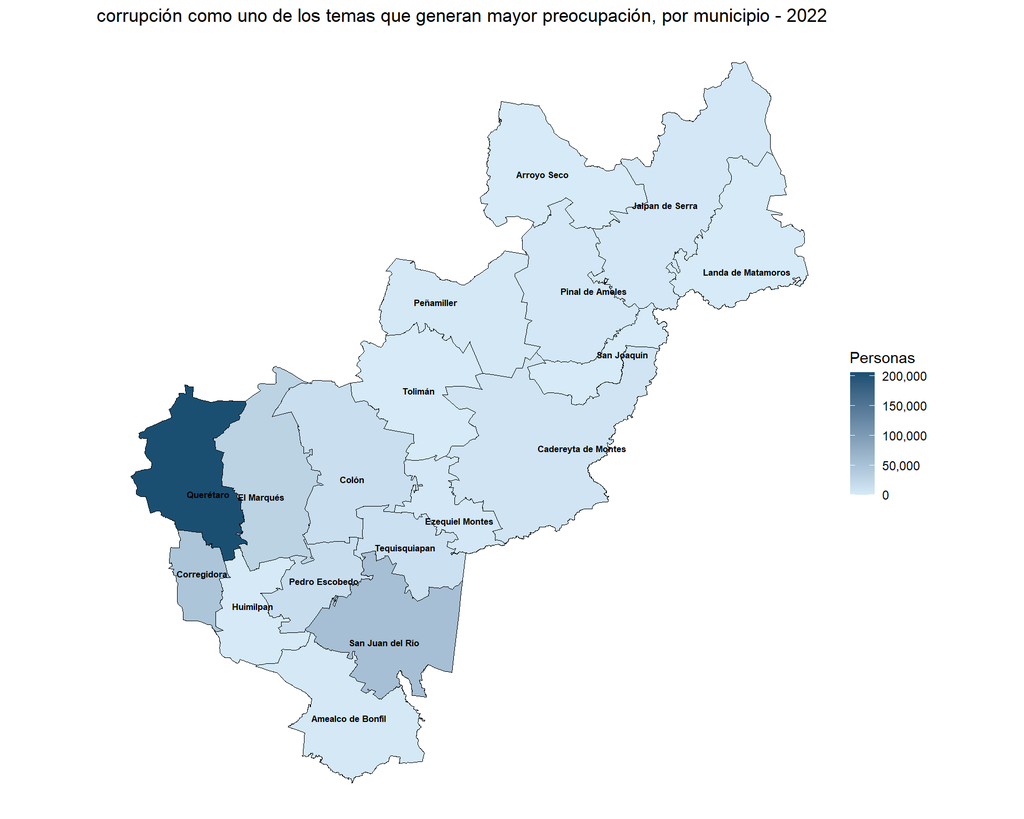

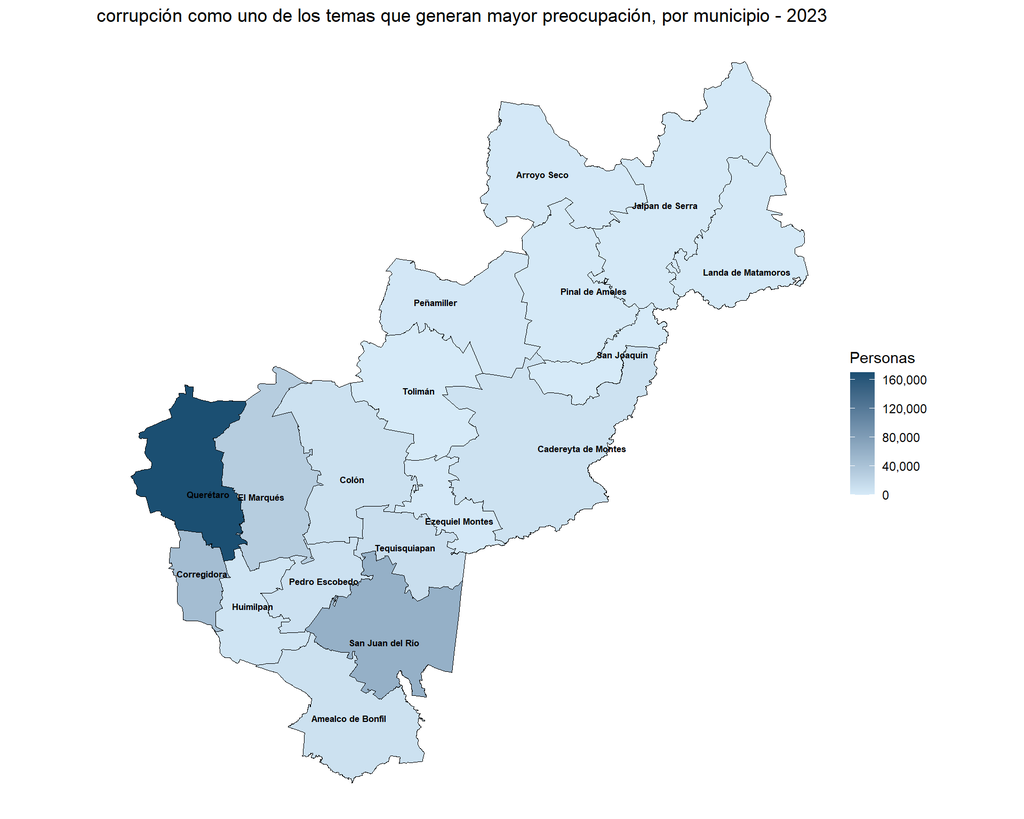

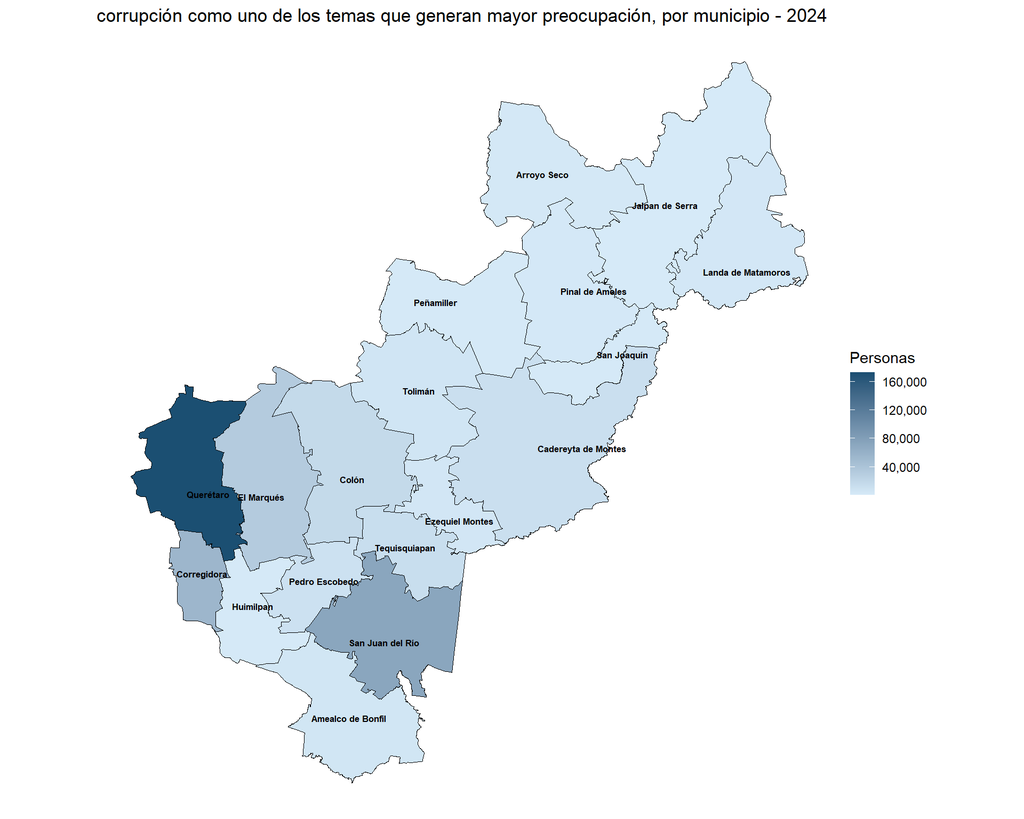

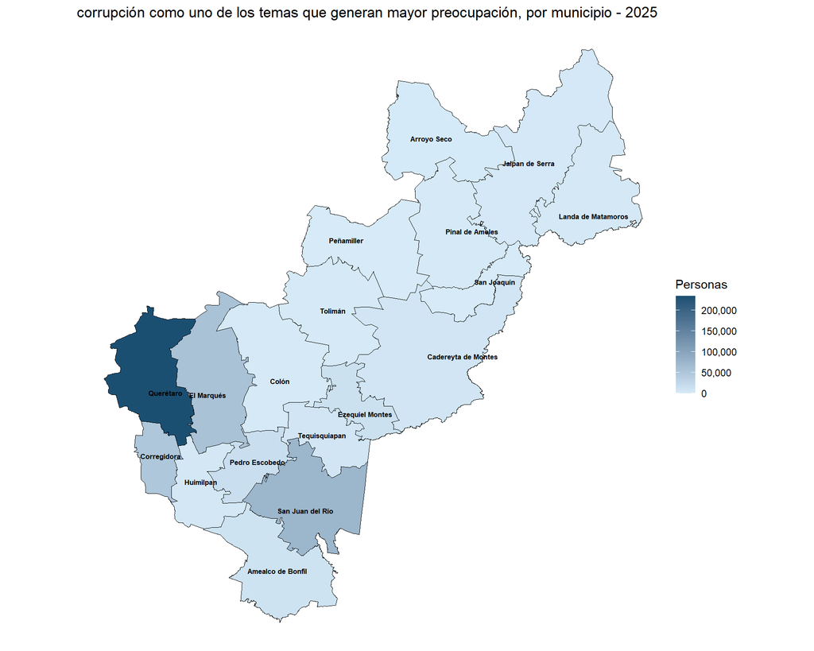

## 2.2 Guardia Nacional

La confianza institucional y la percepción sobre la disposición de las autoridades para apoyar a la ciudadanía dictan, en gran medida, la legitimidad de las fuerzas de seguridad. La ENVIPE levanta estos datos precisamente durante los meses de marzo y abril de cada año, permitiendo capturar el sentir de la población de 18 años y más respecto al desempeño de los cuerpos federales.

En esta sección se analiza cuántas personas consideran que la Guardia Nacional tiene una disposición real de ayuda en los distintos municipios del estado de Querétaro.

La confianza institucional y la percepción sobre la disposición de las autoridades para apoyar a la ciudadanía dictan, en gran medida, la legitimidad de las fuerzas de seguridad. La ENVIPE levanta estos datos precisamente durante los meses de marzo y abril de cada año, permitiendo capturar el sentir de la población de 18 años y más respecto al desempeño de los cuerpos federales.

En esta sección se analiza de forma histórica (periodo 2022-2025) cuántas personas consideran que la Guardia Nacional tiene una disposición real de ayuda en los distintos municipios del estado de Querétaro.

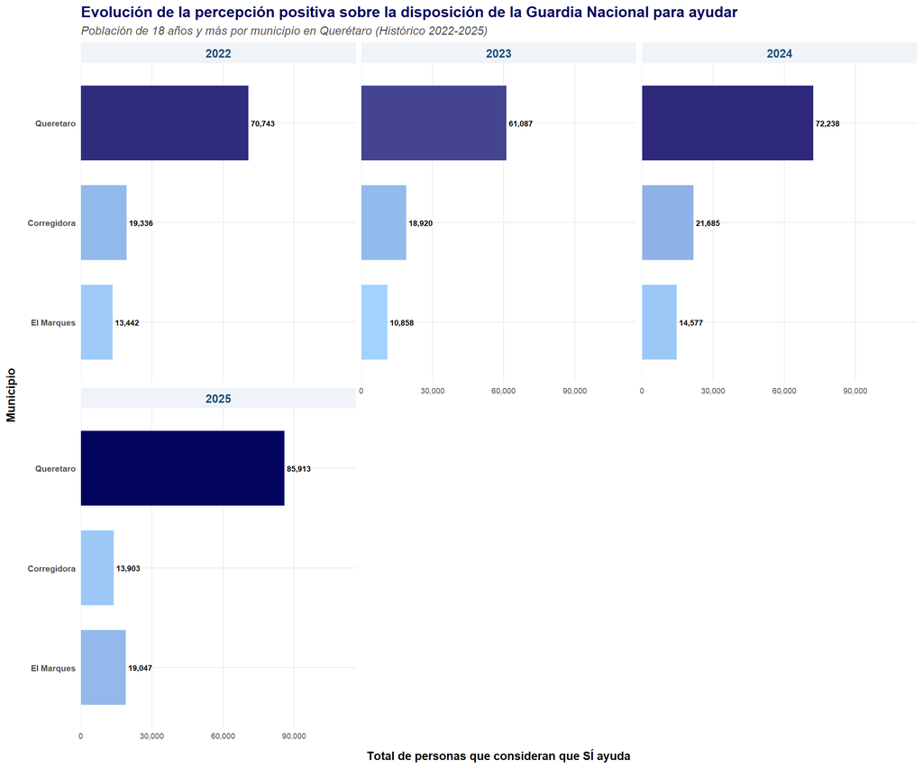

Cabe destacar que, al realizar análisis históricos o al contrastar bases de datos de series de tiempo más largas de la ENVIPE, la ausencia de registros o variables asociadas a esta corporación en ciertos años se debe estrictamente a que la Guardia Nacional es una institución de reciente creación (fundada a mediados de 2019), por lo que su incorporación en los cuestionarios de percepción ciudadana del INEGI se dio de manera progresiva a partir de dicha fecha histórica.

## 2.3 Percepcion sobre la seguridad al caminar por las noches

La percepción de seguridad en los espacios públicos es un elemento importante para comprender la calidad de vida y el bienestar de la población. Caminar por la noche en los alrededores de la vivienda representa una actividad cotidiana que refleja el nivel de confianza que tienen las personas en su entorno inmediato.

A través de la ENVIPE, es posible identificar cómo percibe la población de 18 años y más las condiciones de seguridad en su municipio, clasificando sus respuestas en categorías que van desde muy segura hasta muy insegura. El análisis de esta información permite observar diferencias territoriales y cambios en la percepción ciudadana a lo largo del tiempo.

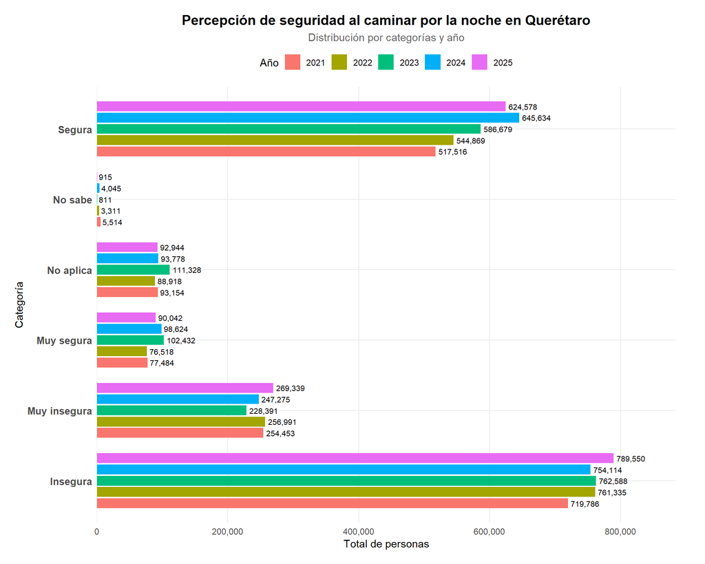

En términos generales, las categorías asociadas con percepción negativa de seguridad (insegura y muy insegura) concentran una proporción importante de la población en todos los años observados. Esto indica que una parte significativa de la ciudadanía percibe riesgos al transitar por espacios públicos durante la noche, lo cual refleja condiciones de vulnerabilidad y desconfianza en el entorno inmediato.

Asimismo, la categoría segura también presenta niveles elevados, lo que evidencia que la percepción ciudadana no es homogénea y que coexisten experiencias diferenciadas respecto a la seguridad pública. Esta variabilidad puede relacionarse con factores territoriales, nivel de urbanización, iluminación pública, presencia policial y experiencias personales o comunitarias de victimización.

La categoría muy segura registra valores considerablemente menores en comparación con las percepciones intermedias y negativas, lo que sugiere que son relativamente pocas las personas que manifiestan una percepción plenamente favorable respecto a la seguridad nocturna en su entorno.

Por otro lado, las categorías no sabe y no aplica presentan participaciones reducidas, lo que indica que la mayoría de la población sí cuenta con una percepción definida sobre las condiciones de seguridad en su colonia o comunidad.

## Análisis a nivel municipal

Observemos en las siguientes imagenes lo que la poblacion de cada municipio del estado de Quéretaro opina sobre este tema.

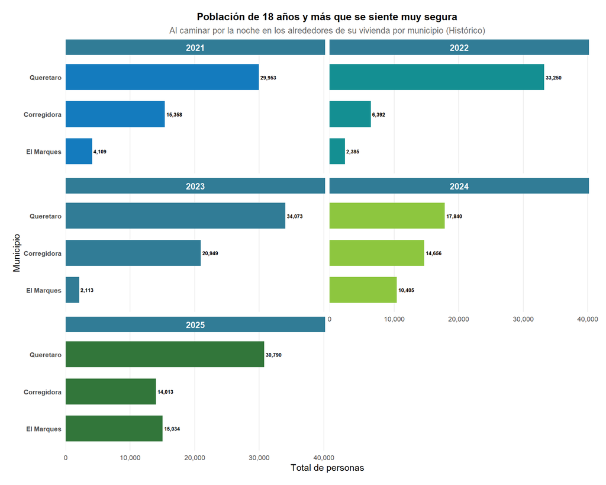

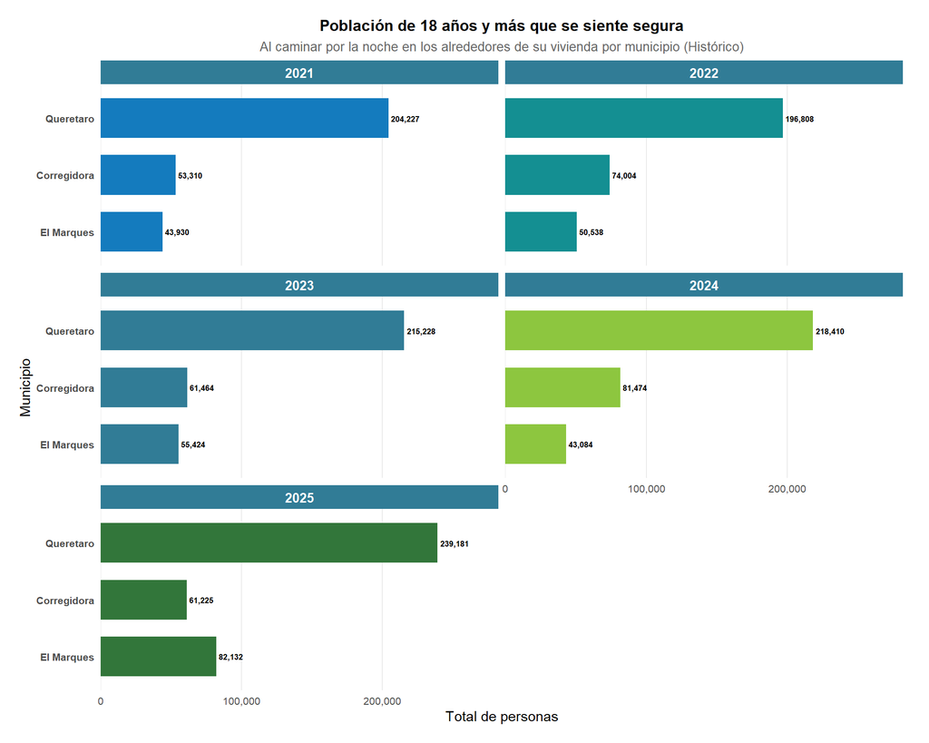

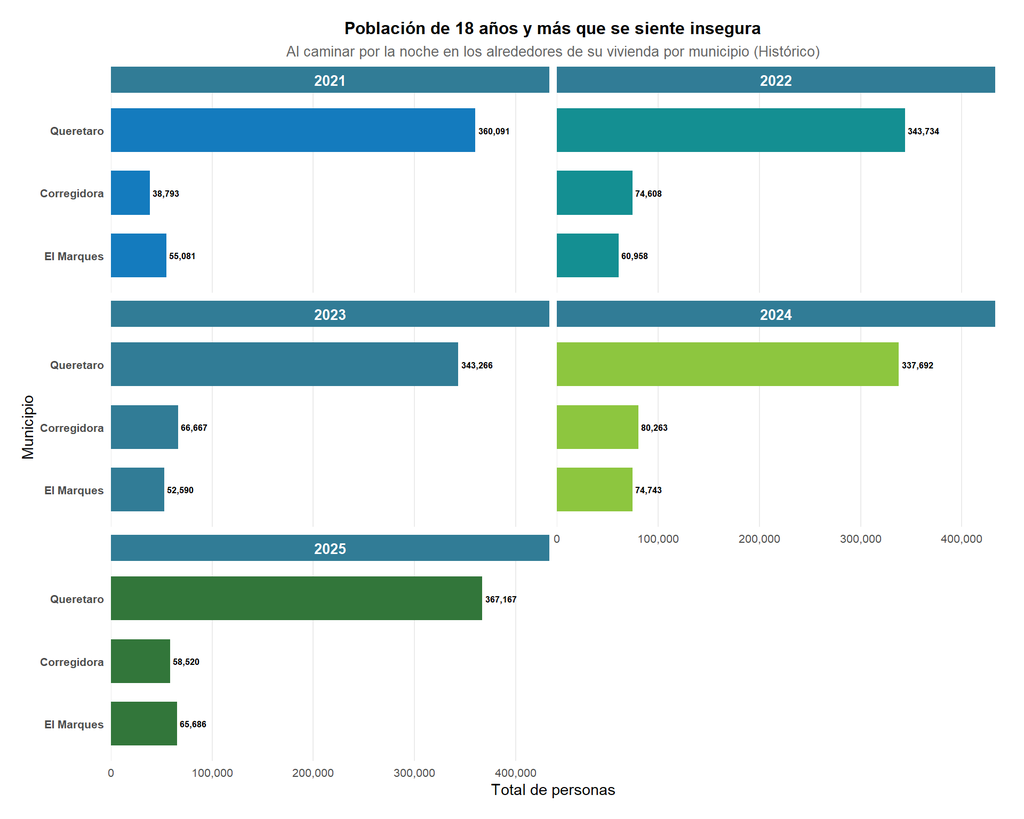

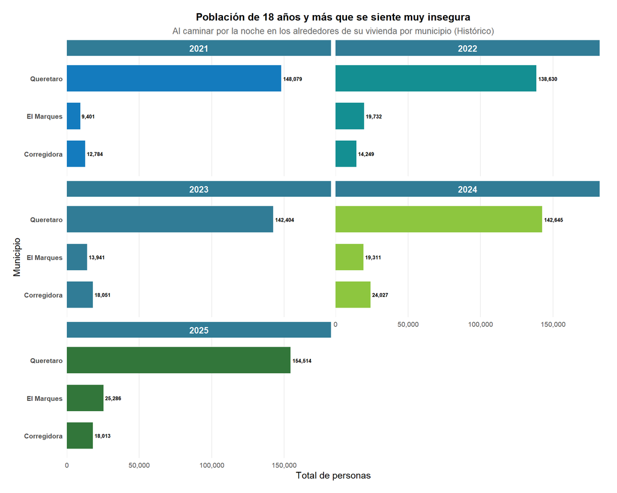

En general, se observa que la mayoría de la población se concentra en las categorías de segura e insegura, lo que indica que existen opiniones divididas sobre qué tan tranquilo es caminar por la noche cerca de sus viviendas.

En algunos municipios hay más personas que se sienten seguras o muy seguras, lo que puede relacionarse con mejores condiciones de iluminación, vigilancia o convivencia comunitaria. En cambio, otros municipios presentan niveles más altos de población que se siente insegura o muy insegura, reflejando una mayor preocupación por la delincuencia o por las condiciones del entorno urbano.

También se pueden notar diferencias importantes entre municipios grandes y pequeños. Los municipios con mayor población suelen registrar cantidades más altas en casi todas las categorías, especialmente en las percepciones de inseguridad. Esto puede deberse a una mayor actividad urbana, tráfico, movilidad y exposición a situaciones de riesgo.

Al comparar los años, las gráficas permiten identificar si la percepción de seguridad mejora o empeora con el tiempo. En algunos casos la sensación de inseguridad aumenta, mientras que en otros parece mantenerse más estable. Esto ayuda a entender cómo percibe la población los cambios en su entorno cotidiano.

## 2.4 Percepción futura sobre la seguridad pública en su colonia

La percepción ciudadana sobre el futuro de la seguridad pública permite conocer las expectativas que tiene la población respecto a las condiciones de seguridad en su colonia o comunidad. Este indicador resulta relevante porque refleja no sólo la situación actual que perciben las personas, sino también el nivel de confianza o preocupación que tienen sobre los cambios que podrían ocurrir en los próximos meses.

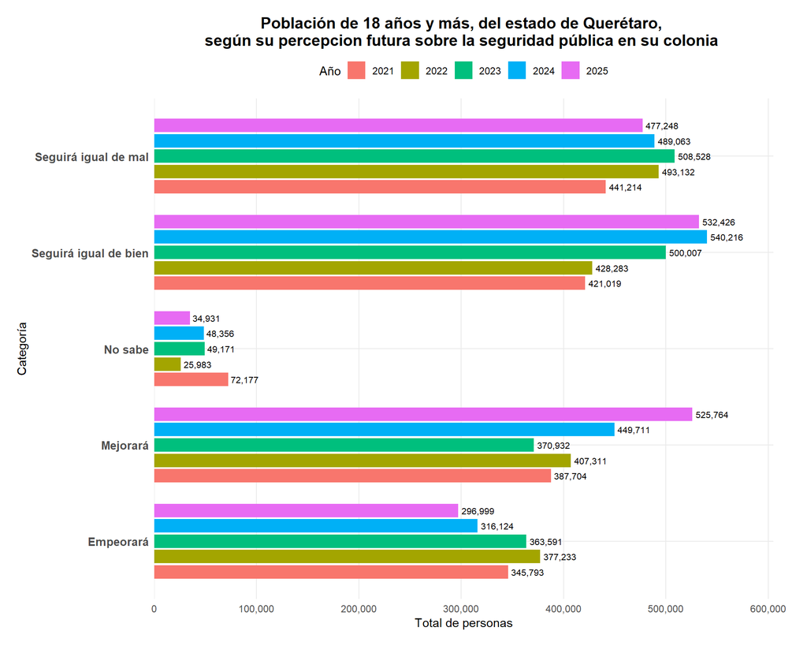

En general, puede observarse que muchas personas consideran que la situación permanecerá igual, ya sea “igual de bien” o “igual de mal”, lo que refleja cierta percepción de estabilidad en las condiciones de seguridad.

Sin embargo, también existe una cantidad importante de personas que consideran que la seguridad podría empeorar. Esto indica que parte de la población mantiene preocupación o incertidumbre sobre la situación de seguridad en los próximos meses. Factores como la delincuencia, las experiencias personales, las noticias o la percepción de vigilancia pueden influir en esta opinión.

En términos generales, la gráfica refleja que la percepción ciudadana sobre la seguridad pública está dividida y que muchas personas aún muestran preocupación respecto al futuro de su entorno.

## Análisis a nivel municipal

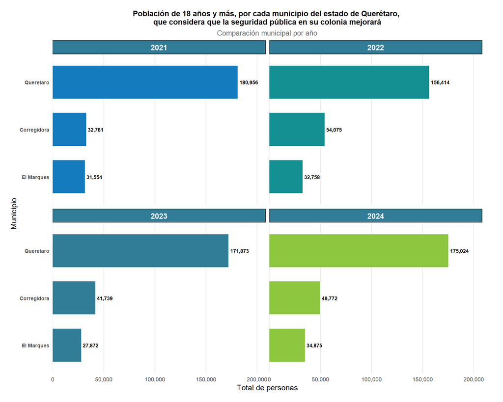

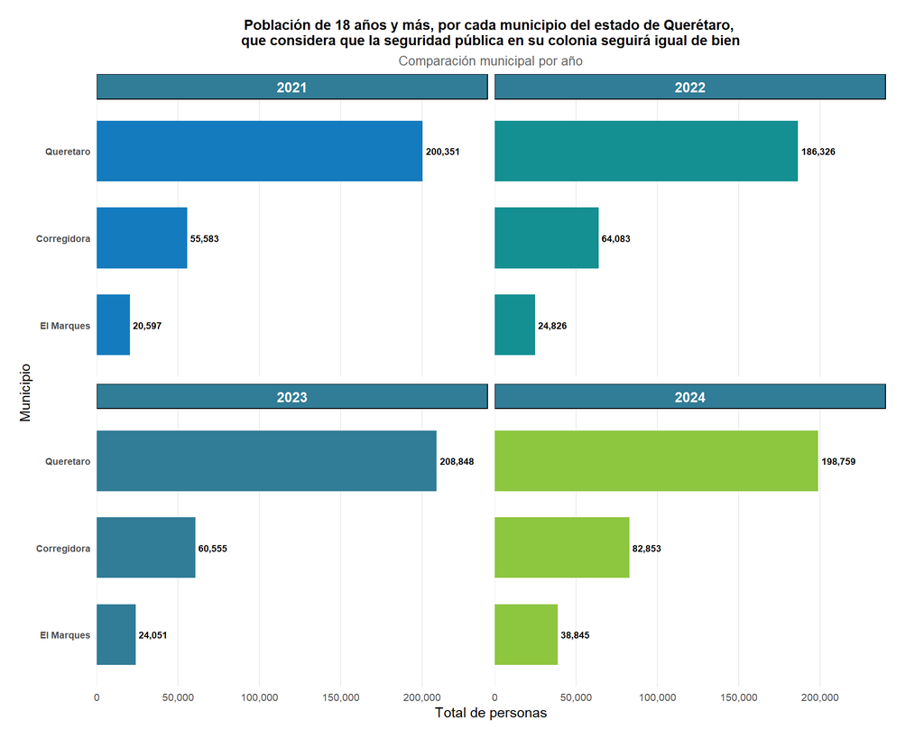

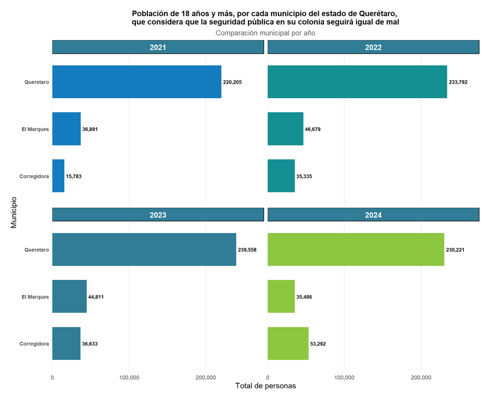

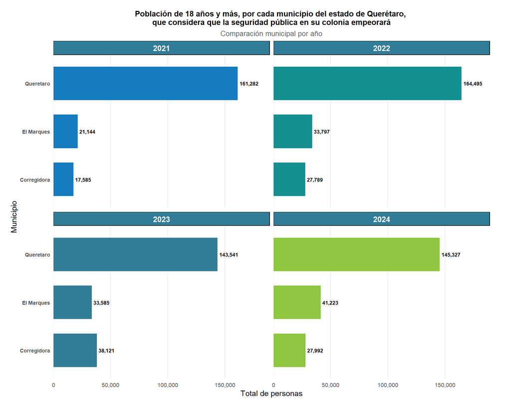

En los municipios con mayor población, normalmente se observan cantidades más altas en todas las categorías. Esto no necesariamente significa que sean los más inseguros, sino que concentran un mayor número de habitantes y, por lo tanto, más respuestas dentro de la encuesta.

En varios municipios destaca la categoría “seguirá igual de mal” o “empeorará”, lo cual refleja preocupación de la población sobre las condiciones de seguridad en su entorno. Esto puede relacionarse con problemas cotidianos como robos, falta de iluminación, percepción de poca vigilancia o desconfianza en las instituciones.

Por otro lado, algunos municipios muestran una percepción más positiva, donde más personas consideran que la seguridad podría mejorar o mantenerse bien. Esto puede asociarse con un mayor sentido de tranquilidad comunitaria o con una percepción favorable de las acciones de seguridad pública.

Al comparar los años, las gráficas también permiten identificar cambios en la percepción ciudadana. En algunos municipios la preocupación parece aumentar, mientras que en otros se mantiene más estable. Esto ayuda a entender cómo evoluciona la percepción de seguridad en distintas regiones del estado.

En conjunto, las gráficas muestran que la percepción sobre el futuro de la seguridad pública varía considerablemente entre municipios y que la experiencia cotidiana de la población influye directamente en cómo evalúan la seguridad de su comunidad.

## 2.5 Confianza vecinal

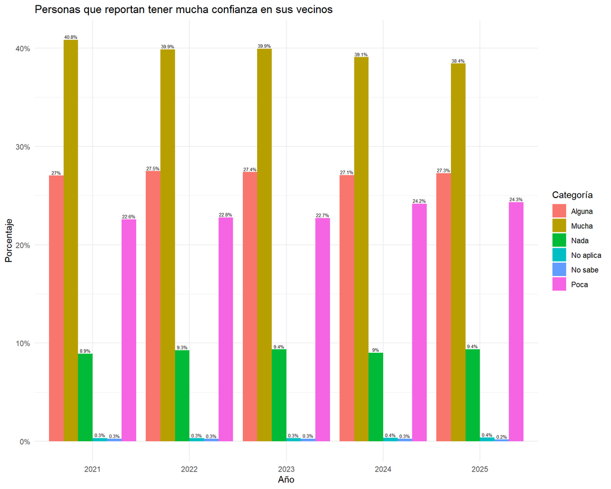

La percepción de confianza vecinal en Querétaro se mantiene más fuerte en los municipios con mayor dinamismo urbano y densidad poblacional, aunque las diferencias observadas parecen responder más al volumen de habitantes que a una ausencia de relaciones comunitarias en los municipios pequeños.

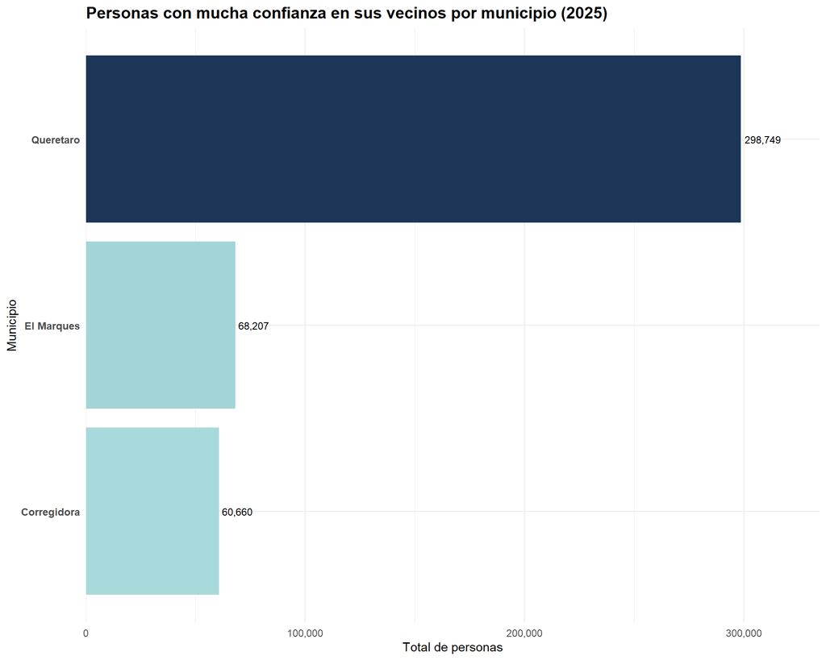

## 3.Impacto de la delincuencia en actividades cotidianas

## 3.1 Trabajo inseguro

El entorno laboral no solo representa el motor económico de las familias en Querétaro, sino también uno de los espacios donde la población adulta pasa la mayor parte de su día. La ENVIPE capta el sentir de la población económicamente activa durante los meses de marzo y abril, permitiendo evaluar si las dinámicas de seguridad externa han logrado permear negativamente en los centros de trabajo.

A continuación, se presenta la evolución histórica (2021-2025) del volumen de personas de 18 años y más que cuentan con un trabajo y consideran que su espacio laboral es inseguro, desglosado por municipio.

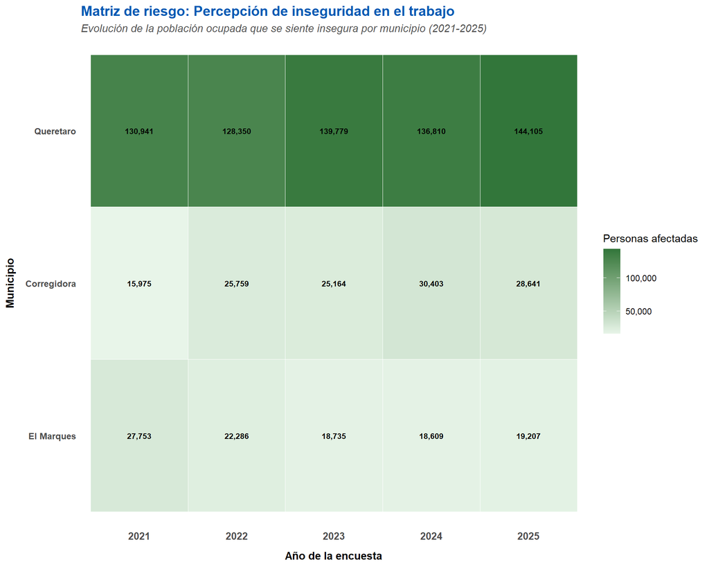

## 3.2 Abandono escolar por temor a ser víctimas de la delincuencia

La inseguridad puede afectar distintas actividades de la vida cotidiana, incluyendo la asistencia a espacios educativos. El temor a ser víctima de un delito puede provocar cambios en los hábitos de la población, limitando la movilidad y reduciendo la participación en actividades académicas o de formación.

A través de la ENVIPE, es posible identificar a la población de 18 años y más que manifestó haber dejado de asistir a la escuela debido al miedo relacionado con la delincuencia. El análisis de esta información permite observar cómo la percepción de inseguridad impacta en el acceso y permanencia en los espacios educativos, así como identificar diferencias entre municipios del estado de Querétaro y cambios a lo largo del tiempo.

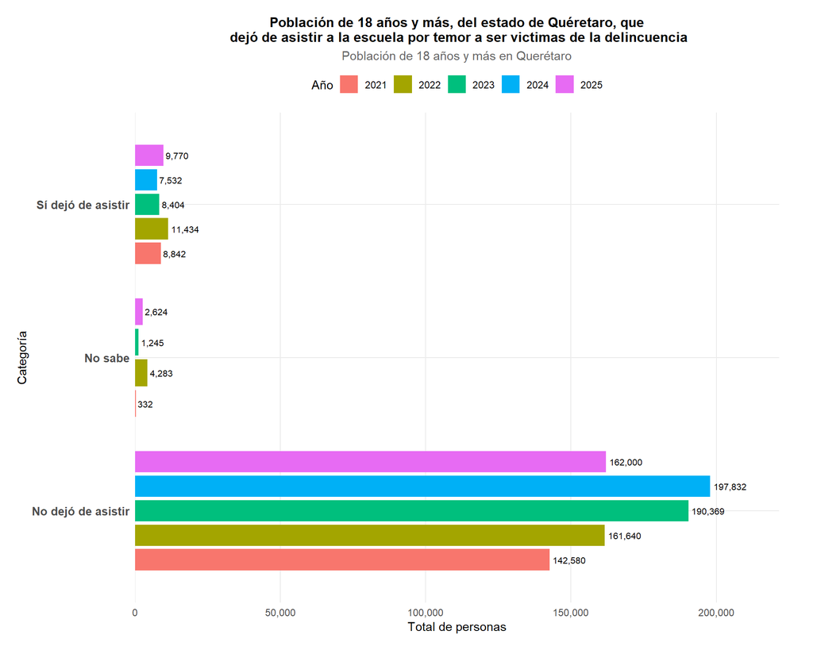

Aunque la mayor parte de la población indica que no dejó de asistir, también se observa que existe un grupo de personas cuya vida académica sí se vio afectada por la percepción de inseguridad.

Este resultado refleja que la inseguridad no solo impacta en la tranquilidad de las personas, sino también en actividades importantes como la educación. El miedo a sufrir un delito puede influir en la decisión de dejar de acudir a clases, especialmente cuando los trayectos se consideran peligrosos o cuando existe poca confianza en las condiciones de seguridad del entorno.

A lo largo de los años analizados, la gráfica permite identificar si esta problemática aumenta, disminuye o se mantiene estable. Cuando el número de personas que dejan de asistir a la escuela crece, puede interpretarse como una señal de mayor preocupación social respecto a la delincuencia y sus efectos en la vida cotidiana.

Por otro lado, el hecho de que la mayoría de las personas responda que no dejó de asistir muestra que, aunque la inseguridad afecta a una parte de la población, no impacta de la misma manera a todos los sectores. Sin embargo, incluso cantidades relativamente pequeñas son importantes, ya que representan personas cuya formación educativa se vio limitada por el temor y la percepción de riesgo.

## Análisis a nivel municipal

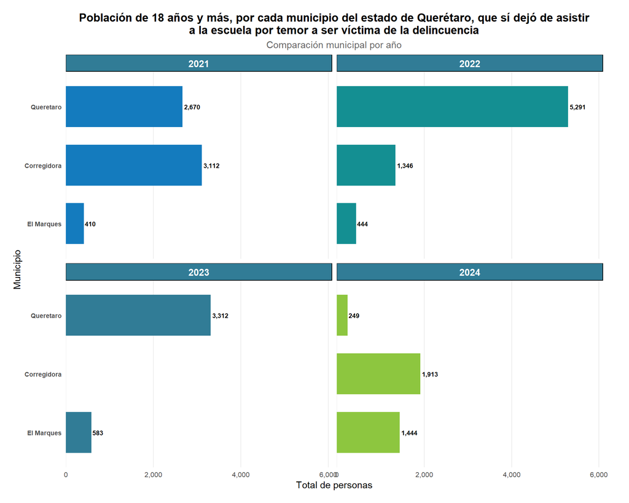

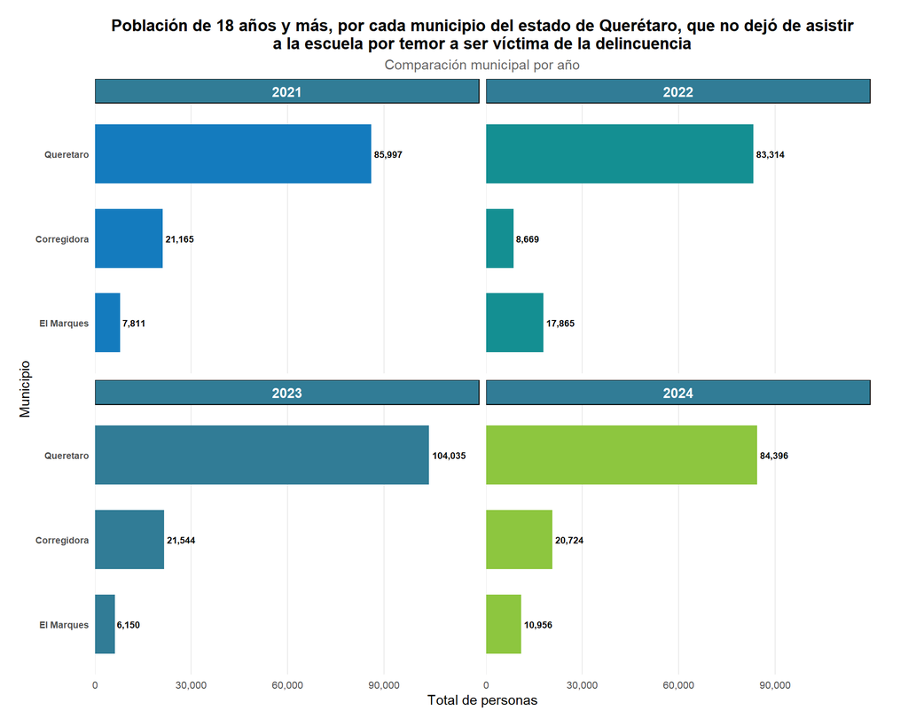

En general, la mayoría de las personas respondió que no dejó de asistir a la escuela por temor a la delincuencia; sin embargo, también existen municipios donde una parte de la población sí reportó haber abandonado temporalmente sus actividades escolares debido al miedo o a la percepción de inseguridad.

Los municipios con mayor población suelen presentar cantidades más altas de personas en todas las categorías, especialmente en la respuesta de “no dejó de asistir”. Esto ocurre porque concentran un mayor número de habitantes y, por lo tanto, más respuestas dentro de la encuesta.

En algunos municipios se observan valores más elevados en la categoría “sí dejó de asistir”, lo que puede reflejar mayores preocupaciones relacionadas con la seguridad, trayectos considerados peligrosos, poca iluminación, inseguridad en el transporte o temor a ser víctima de algún delito. Aunque en muchos casos las cantidades no son tan grandes en comparación con otras categorías, siguen siendo relevantes porque representan personas cuya educación se vio afectada por el miedo.

También se pueden notar diferencias entre municipios urbanos y rurales. En ciertos municipios pequeños los valores son más bajos, mientras que en municipios con mayor actividad urbana la percepción de riesgo puede influir más en las decisiones cotidianas de la población.

## 3.3 Robo de celular

De acuerdo con la metodología de la ENVIPE, este tipo de incidentes se clasifica dentro de la victimización personal. Esto refleja que el celular es uno de los bienes más vulnerables al tratarse de un objeto de uso cotidiano, portátil y de fácil comercialización, por lo que suele ser un objetivo frecuente en delitos contra el patrimonio.

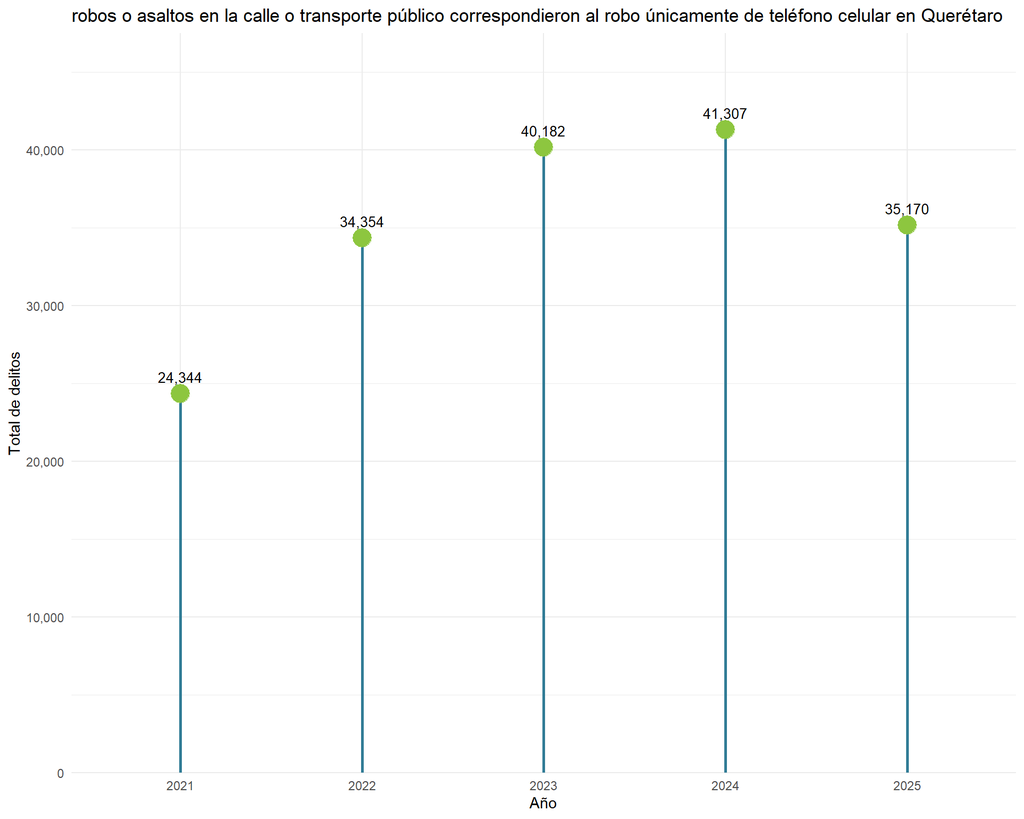

Asimismo, los datos incluyen la suma de los delitos de robo o asalto en la calle o transporte público captados por la encuesta, hayan sido o no denunciados ante el Ministerio Público o Fiscalía Estatal. También se consideran los casos en los que el (la) informante seleccionó la opción “Nada”, e incluye robo relacionado con una visita a un banco o cajero automático.

## 4. Estrategias de prevención y respuesta comunitaria

## 4.1 Adquirir un Perro guardián

Las gráficas muestran una respuesta concreta de los hogares ante su entorno social en Querétaro. La decisión de comprar un perro guardián puede interpretarse como una estrategia de protección dentro del contexto de la Delincuencia, fenómeno social constituido por el conjunto de actos delictivos que se cometen de manera dolosa en un tiempo y lugar determinados. Este comportamiento refleja cómo las familias adaptan sus acciones según las condiciones de seguridad percibidas en su comunidad(Cada hogar puede decidir tomar mas de una medida de proteccion ademas de esta como cambiar puertas o ventanas,colocar rejas o bardas, colocar candados,ect).

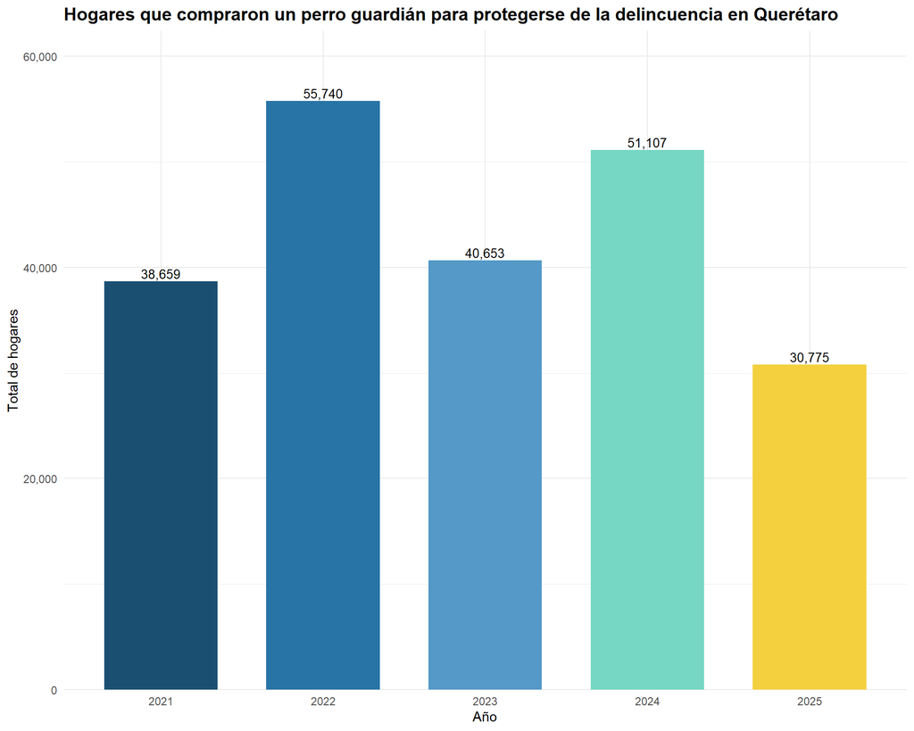

Asimismo, los datos pueden relacionarse con el temor, entendido como el sentimiento de inseguridad que experimenta la población ante una posible amenaza. Aunque no todas las personas hayan sido víctimas directas, la percepción de riesgo influye en la toma de decisiones. Esto demuestra que la sensación de inseguridad también genera cambios en la vida cotidiana de los hogares.

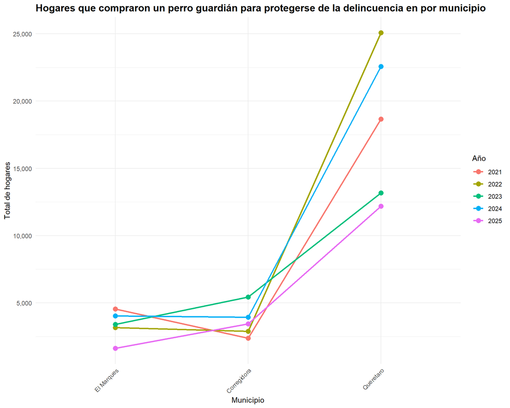

Finalmente, estas gráficas pueden vincularse con la Prevención de la violencia y/o la delincuencia, ya que prevenir implica anticiparse a posibles daños y actuar con anticipación. La adquisición de un perro guardián representa una medida preventiva individual que busca disminuir el riesgo y sus consecuencias. De esta manera, se observa cómo las familias implementan acciones para fortalecer su seguridad frente a posibles situaciones de peligro.

## 4.2 Organización vecinal por alumbrado

Un entorno iluminado es una de las primeras barreras físicas contra la delincuencia. Cuando el alumbrado público falla, aumenta la percepción de inseguridad y se pone a prueba la capacidad de respuesta y organización de la propia comunidad.

A continuación, se presenta la evolución histórica (2021-2025) a nivel estatal en Querétaro de dos indicadores clave: el volumen total de personas de 18 años y más que sufren por la falta de luminarias en su colonia y, de ellos, qué porcentaje decidió organizarse con sus vecinos para solucionar el problema.

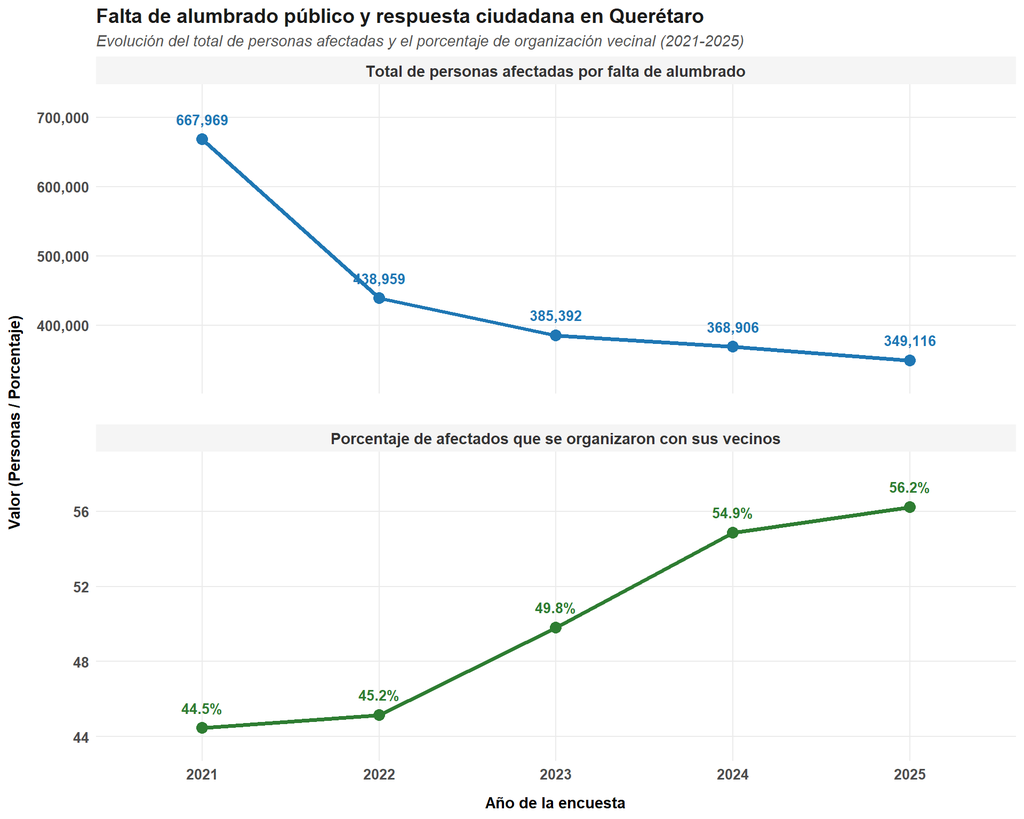

A continuación, se presenta el panorama detallado para el año 2025 por municipio, contrastando el volumen total de personas afectadas por la falta de alumbrado frente al porcentaje de dicha población que logró organizarse para resolverlo.

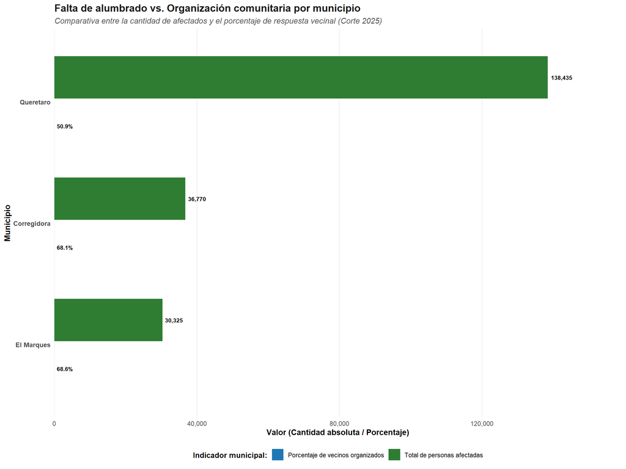

## 5. Conclusiones

El análisis de las diez preguntas seleccionadas en esta investigación demuestra que la seguridad pública no puede medirse únicamente a través de las tasas de homicidios o delitos de alto impacto. La verdadera dimensión del problema se vive en el desgaste silencioso de la rutina de los ciudadanos: en el transporte público, en las aulas, en los espacios de trabajo y al caer la noche.

A partir de los hallazgos obtenidos, es posible sintetizar la realidad del entorno delictivo y social en tres grandes pilares:

- **1.** La privatización de la seguridad y la pérdida de libertades cotidianas Los datos de 2024 revelan un impacto directo en el bolsillo y el desarrollo de los mexicanos. Por un lado, la delincuencia de alta frecuencia —representada masivamente por el robo exclusivo de teléfonos celulares en la calle y el transporte— obliga a la sociedad a modificar su entorno doméstico, traduciéndose en gastos preventivos como la adopción de perros guardianes para blindar el hogar.

El costo más grave, sin embargo, no es económico sino humano: cuando una parte de la población deja de asistir a la escuela por temor a la delincuencia, el miedo deja de ser una sensación y se convierte en un freno para el desarrollo educativo y el futuro de los jóvenes del país.

- **2.** Los espacios de vulnerabilidad: El trabajo, la noche y la calle El diagnóstico de percepción de 2025 enciende alarmas sobre los lugares donde pasamos la mayor parte del tiempo. La delincuencia ha logrado traspasar las fronteras de lo privado: una porción significativa de la población ocupada percibe su propio espacio laboral como un entorno inseguro, restándole bienestar a la actividad productiva.

Esta vulnerabilidad se agudiza drásticamente al caer el sol. El miedo generalizado a caminar solos por la noche en los alrededores de la vivienda está íntimamente ligado a las deficiencias de infraestructura. Aquí, el caso de Querétaro resulta emblemático: demuestra que la falta de alumbrado público actúa como el primer detonante de la percepción de riesgo, pero también pone a prueba el tejido social, sirviendo como un catalizador para que los vecinos decidan organizarse de forma autónoma ante la ausencia de soluciones inmediatas.

- **3.** El dilema institucional: Confianza vecinal, corrupción y fuerzas federales El cierre del periodo de estudio en 2025 nos muestra una sociedad civil que navega entre la desconfianza institucional y el refugio comunitario. Mientras que la corrupción se mantiene firmemente en la mente de los ciudadanos como uno de los problemas prioritarios y más preocupantes en la mayoría de las entidades federativas, la población busca equilibrios:

Por un lado, la confianza depositada en los propios vecinos se convierte en la primera red de seguridad y apoyo ante la delincuencia local.

Por el otro, a nivel macro, la Guardia Nacional retiene un voto de confianza importante al ser percibida por la mayoría como una institución dispuesta a ayudar, consolidándose como el principal bastión de legitimidad del Estado en el territorio.

## 6. Referencias

2021 Instituto Nacional de Estadística y Geografía (INEGI). (2021). Encuesta Nacional de Victimización y Percepción sobre Seguridad Pública (ENVIPE) 2021. https://www.inegi.org.mx/programas/envipe/2021/

2022 Instituto Nacional de Estadística y Geografía (INEGI). (2022). Encuesta Nacional de Victimización y Percepción sobre Seguridad Pública (ENVIPE) 2022. https://www.inegi.org.mx/programas/envipe/2022/

2023 Instituto Nacional de Estadística y Geografía (INEGI). (2023). Encuesta Nacional de Victimización y Percepción sobre Seguridad Pública (ENVIPE) 2023. https://www.inegi.org.mx/programas/envipe/2023/

2024 Instituto Nacional de Estadística y Geografía (INEGI). (2024). Encuesta Nacional de Victimización y Percepción sobre Seguridad Pública (ENVIPE) 2024. https://www.inegi.org.mx/programas/envipe/2024/

2025 Instituto Nacional de Estadística y Geografía (INEGI). (2025). Encuesta Nacional de Victimización y Percepción sobre Seguridad Pública (ENVIPE) 2025. https://www.inegi.org.mx/programas/envipe/2025/